# What’s in a wine review?

### I don’t understand wine. Can data fix that?

I *like* wine, but there are several layers of complication and fussyness that, for me, get in the way.

Whiskey, think I understand. That’s thanks to some great analysis of [whiskey data](https://www.mathstat.strath.ac.uk/outreach/nessie/nessie_whisky.html), showing that for all the many different ways we can describe them, 60% of the difference among whiskies is due to one of two main features, either the “smokiness” or the “body” - and by sampling varieties along these axes, you can develop a thoughtful appreciation for whiskey.

Wine seems more complicated. While people typically use around a dozen terms to describe whiskies, people use hundreds of terms to describe wines, and it would be lovely to have a simple framework for parsing how these descriptions relate wines to one another. I compiled a [list](https://github.com/sadacca/wineR/blob/master/wine_terms.txt) capturing ~300 taste-related terms used to describe wine, and the question I’m wondering is: what’s the simplest framework we can use to think about the taste of wine? Do we need all ~300 terms to tell reds from whites? How about Pinot Grigio from Pinot Noirs or Merlot from Malbec?

Before we dig into the data - there’s one big caveat: if you dye a white wine red, [people start describing the taste in terms of a red wine](http://www.realclearscience.com/blog/2014/08/the_most_infamous_study_on_wine_tasting.html). The down side of this is that our ‘taste-terms’ might not be based on taste alone. I’m okay with that. The goal here is to better understand wines, and if this data give us information beyond “red wine is different than white wine”, that’s terrific. And, on the plus side: it should be pretty easy to tell white wines from red.

So first - after loading the wine review data[^1], and cleaning and processing our database of wine reviews we’ll create a simple model of how wine reviews map on to our selected wine terms. This very simple model is often called a “bag-of-words” model. While there are many more complex ways of relating our wine reviews to one another (e.g. using context words in a continuous-bag-of-words or skip-gram model), it’d be quite promising if even this simple model could effectively compare wine reviews.

### Can we get a simpler picture of how wines relate by looking for similarities in how wine terms are used?

Once we have our model of wine reviews, let’s try and simplify it further. We’ll use principal components analysis (PCA) to see if there are a few features (i.e. principle components or PCs) that help separate wines from one another.

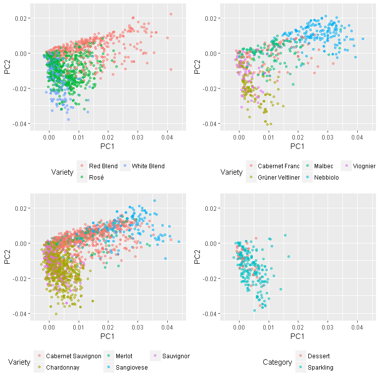

So, this is pretty nice for our simplified model. Projecting our wines onto the two featues that best seperate wines from one another (PC1 and PC2), we can in fact separate white wines from reds just like we expected. As a nice sanity check, it looks like Rosé wines fall right across the edges of the red/white distributions which makes a fair bit of sense. Even nicer though, and for me way more interesting is that the difference *within* reds is just as big as the differences *between* whites and reds. This IS quite surprising. It means that on this red-white axis (and it really does seem to be a single dimension of variation) there are white-ish reds and ‘average’ reds and really-red reds. Better yet, there’s some reasonable variability among how whites are described too, and some whites are really white. It just so happens two of my personal favorite varietals sit at the edge of this white-red axis, with “Grüner Veltliner” being among the whitest of the whites and “Sangiovese” being among the reddest of the reds. So far, I’m thrilled with this simple result. But with all the individual datapoints for each wine overlain, it’s tough to get a sense for exactly how each wine variety, on average, relates to on another. If we take the center of each wine variety’s cloud of points, do we see look quite as good?

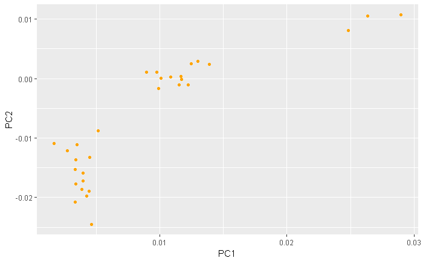

This is a terrific bit of insight into how varietals compare to one another, on average. While the spread of group means obviously not as big as individual examples, there is a bit of variation within the white and red clusters (with a fun little “really red” group out at the top right corner of the plot). This gives us a simple framework for thinking about different grapes. But what are the terms that were important for making these principle components? What makes up this white-red axis? Let’s check out the loadings on the first two PCs.

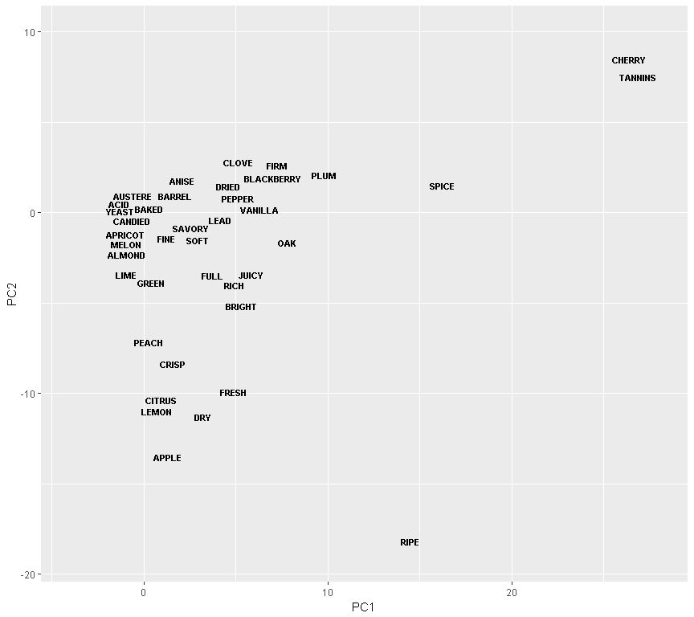

### Can we identify what kind of wine was reviewed based on these features?

Here’s an interesting thought: Could we use this model to find individual wines that are particularly good examples of their class (like an ur-merlot) or wines that really taste like other things (e.g. can I find a cabernet that tastes like a white wine?). In fact, I just wrote a shiny app to do this, [right here](https://sadacca.shinyapps.io/wine-findr/) if you’re interested in playing with the underlying data.

written by Brian Sadacca, 8.30.2017

[^1]: for all code see associated git repository, code for this was wine_text…Rmd : [https://www.github.com/sadacca/wineR].